# Final Homework

Alanna Bachtlin

7/28/2021

## Precipitation Patterns

*Albasini Dam, South Africa*

### Instructions

**Due 27 July 2021**  
This homework is due by class time on Tuesday. You will upload both the R Markdown document (this file) and the output hypertext markup language (HTML) document (the output knit produces) to your GitHub repository. Please be sure to update your name in the *author* field in the header information of this document. Be careful, the warnings are currently set not to appear; you may wish to turn them on (TRUE) until you are confident in your file.

Your assignment is to produce two graphs based on data from the Albasini Dam weather station in South Africa. First, a bar graph that shows annual precipitation over the period 1980 to 2020. Second, an average monthly precipitation graph with the standard deviation shown as error bars on the figure. For each, you should use ggplot2 to generate nice figures and you should write clear, concise figure captions below each figure in the Rmd document (they should not be a part of your figure). Lastly, you should use a t-test to draw a conclusion about the period 1980-2000 compared to 2000-2020. Along with your t-test results, include a boxplot that compares these populations (hint: use a long data frame format).

This Rmd file will not run correctly. I have included many pieces of code that you will need to get you started; however, you will need to make considerable additions. I have not put in any code that is outright wrong, but I may have removed parts that will make the line not run or not run properly. I have *tried* not to make anything appear misleading - you can tell me if I did a good job.

Lastly, in your Rmd file, you should remove these instructions and begin the assignment with an introduction the two figures and analysis (one or two sentances). The figures and captions, and the t-test results and interpretation are the most important components, thus worth the vast majority of the points of the homework.

### Annual Precipitation

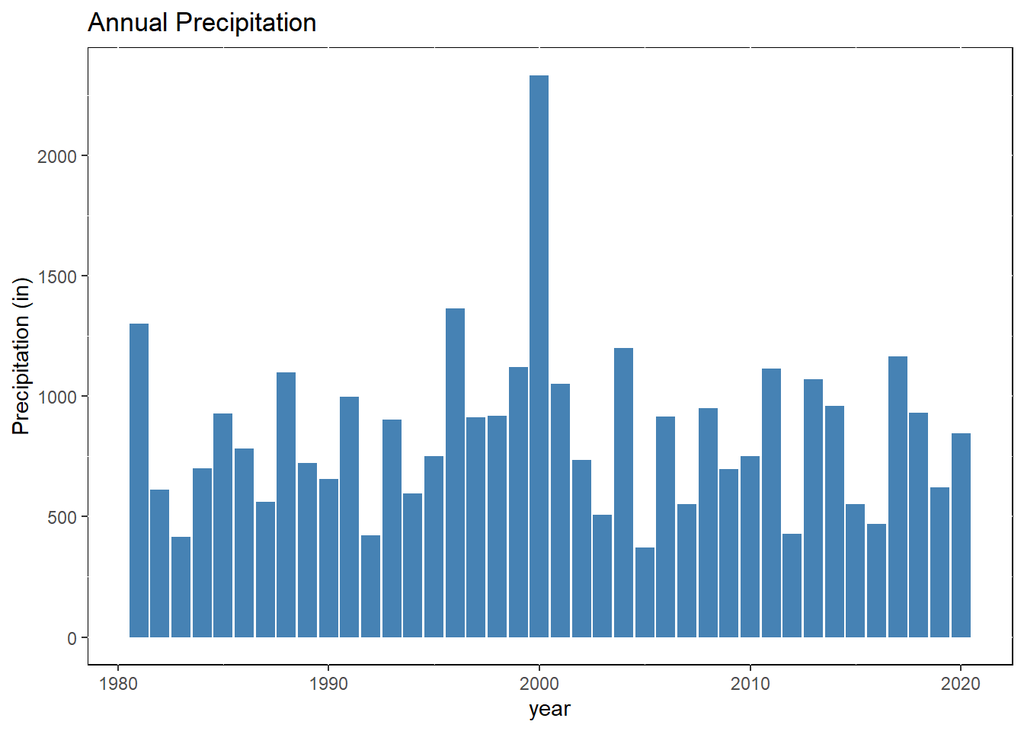

[output not shown]

### Typical Monthly Precipitation

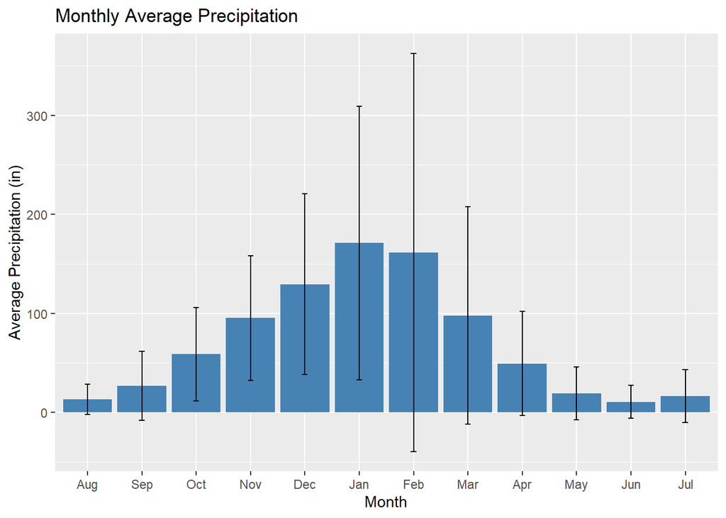

[output not shown]

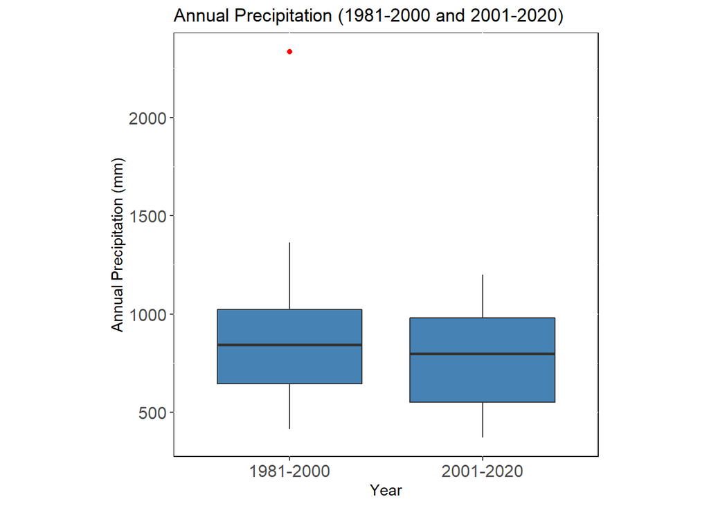